# Lab 2 - Matan Segal

### Rock-Paper-Scissors Game

Business understanding:

Dataset was token from: https://www.kaggle.com/drgfreeman/rockpaperscissors

This dataset contains images of hand gestures from the Rock-Paper-Scissors game collected by Julien de la Bruère-Terreault. The images were captured as part of a project where he developed a Rock-Paper-Scissors game using computer vision and machine learning on the Raspberry Pi.

The dataset contains a total of 2188 images corresponding to the 'Rock' (726 images), 'Paper' (712 images) and 'Scissors' (750 images) hand gestures of the Rock-Paper-Scissors game.

All images are RGB images of 300 pixels wide by 200 pixels high in .png format and all were taken on a green background. The images are separated in three sub-folders named 'rock', 'paper' and 'scissors' according to their respective class.

How many times did you face an argument with a friend or a colleague about random staff that you needed to throw a coin or have something that will be the ‘tie-breaker’, but it was through messaging so you weren’t able to do so? Many argument or decisions are made by playing the Rock-Paper-Scissors game when the conversation accrues face to face, but when messaging we have no ability to do so. In order to solve this problem, we can build an app which will recognize pictures of the hand playing Rock-Paper-Scissors and decide who is the winner.

The app will connect to internet and will ask taking a picture of the users’ hands. Once both will capture the picture, the app will send both players the pictures of the hands and will tell who the winner is. The app will have an advantage of just sending a picture or saying what you chose because the user will need to wait until the other will do his/her ‘move’.

Using this data, we can build a model for the game which can be used in the app. Since it is just a game, the accuracy of the results should not be that high, but in order it to be an official app it should have at least 90% accuracy to determine who the winner is. We can also use plots of the PCA and the sigmoid function in order to check if there are areas where the model will have struggles to decide what move have made and declare those area as ‘undecided’. I would say that when the sigmoid is close to 0.5, in the range of about 0.4 to 0.6 it will be undecided. In this case the app will ask player to take another picture.

First, I will load the picture and represent the pictures

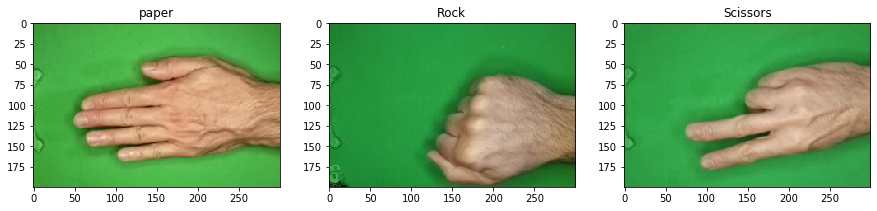

```python
import glob
import matplotlib.pyplot as plt
import matplotlib.image as mpimg
import numpy as np

paper_data = glob.glob('paper/*.png')
rock_data = glob.glob('rock/*.png')
scissors_data = glob.glob('scissors/*.png')

toShowList = [paper_data[0],rock_data[0],scissors_data[0]]
titles = ['paper','Rock','Scissors']

plt.figure(figsize=(15,20))

for i,item in enumerate(toShowList):
    plt.subplot(1, 3, i + 1)
    img = mpimg.imread(item)
    imgplot = plt.imshow(img)
    plt.title(titles[i], size=12)

plt.show()
```

Now, I will make the data into matrixes. Since the color is not important to us for this dataset, I will convert it to a gray scale pictures.

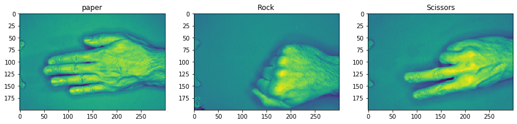

```python
# was token from:
# https://stackoverflow.com/questions/12201577/how-can-i-convert-an-rgb-image-into-grayscale-in-python

def rgb2gray(rgb):

    r, g, b = rgb[:,:,0], rgb[:,:,1], rgb[:,:,2]
    gray = 0.2989 * r + 0.5870 * g + 0.1140 * b

    return gray

for i,item in enumerate(paper_data):
    paper_data[i] = rgb2gray(mpimg.imread(item))

for i,item in enumerate(rock_data):
    rock_data[i] = rgb2gray(mpimg.imread(item))

for i,item in enumerate(scissors_data):
    scissors_data[i] = rgb2gray(mpimg.imread(item))

toShowList = [paper_data[0],rock_data[0],scissors_data[0]]

plt.figure(figsize=(15,20))

for i,item in enumerate(toShowList):
    plt.subplot(1, 3, i + 1)
    imgplot = plt.imshow(item)
    plt.title(titles[i], size=12)

plt.show()
```

```python
print('paper data length: ',len(paper_data))
print('rock data length: ',len(rock_data))
print('scissors data length: ',len(scissors_data))

paper_data[0].shape
```

```
paper data length:  712
rock data length:  726
scissors data length:  750
```

```
(200, 300)
```

```python
# dividing it to a training set (80%) and a test set (20%)
# first 560 images in each set will be for trining, the last 140 for testing


paper_test = paper_data[-140:]
paper_train = paper_data[:560]
rock_test = rock_data[-140:]
rock_train = rock_data[:560]
scissors_test = scissors_data[-140:]
scissors_train = scissors_data[:560]

print('paper_train', len(paper_train))
print('paper_test',len(paper_test))
```

```
paper_train 560
paper_test 140
```

```python
# make a Y vector which is the target for the images:
# 0 - paper
# 1 - rock
# 2 - scissors

Y_train = np.zeros(560*3)
Y_train[560:560*2] = 1
Y_train[-560:] = 2
print(Y_train.shape)
```

```
(1680,)
```

```python
# combain the all train sets into one ordered train set

X_train = paper_train + rock_train + scissors_train
print(len(X_train))
```

```
1680
```

We saw that each picture reprersented by 2D array of 200X300 pixels. Now I will convert it to the features vector:

```python
X_train_fv = []

for item in X_train:
    X_train_fv.append(item.flatten())

X_train_fv = np.array(X_train_fv)
X_train_fv.shape
```

```
(1680, 60000)
```

### Using PCA:

first, I will check where is the 'knee' of reducing the dimentions:

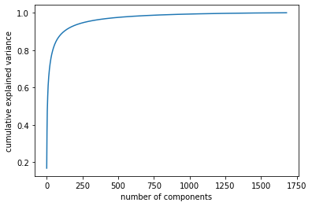

```python
pca = PCA().fit(X_train_fv)
plt.plot(np.cumsum(pca.explained_variance_ratio_))
plt.xlabel('number of components')
plt.ylabel('cumulative explained variance');
```

we can see that there is a clear knee around 200, therefore we will use this number of components

```python
# reduce from 60k to 200 components
from sklearn.decomposition import PCA

n_comp = 200
pca = PCA(n_comp)
X_pca = pca.fit_transform(X_train_fv.copy())
X_pca.shape
```

```
(1680, 200)
```

```python
eigenpics = pca.components_.reshape((n_comp, 200, 300))
eigenpics.shape
```

```
(200, 200, 300)
```

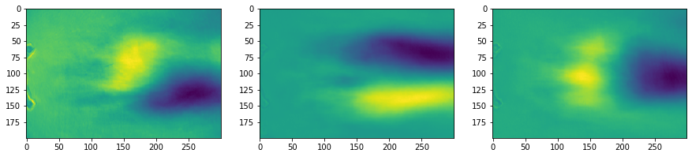

```python
toShowList = [eigenpics[0], eigenpics[1], eigenpics[2]]

plt.figure(figsize=(15,20))
for i,item in enumerate(toShowList):
    plt.subplot(1, 3, i + 1)
    imgplot = plt.imshow(item)

plt.show()
```

### Using Kernel PCA:

```python
from sklearn.decomposition import KernelPCA

kpca = KernelPCA(n_components=n_comp, kernel='rbf',fit_inverse_transform=True,
                 gamma=0.01, remove_zero_eig=True)
X_kpca = kpca.fit_transform(X_train_fv.copy())
X_kpca.shape
```

```
(1680, 200)
```

### Comparing between Kernel PCA and PCA

One way we can compare betweeen the two is reconstruct the picuters back to original form. In the following code I will reconstruct the same image once from the PCA and once for kPCA. I will do it for each group: once for paper, once for rock and once for scissors.

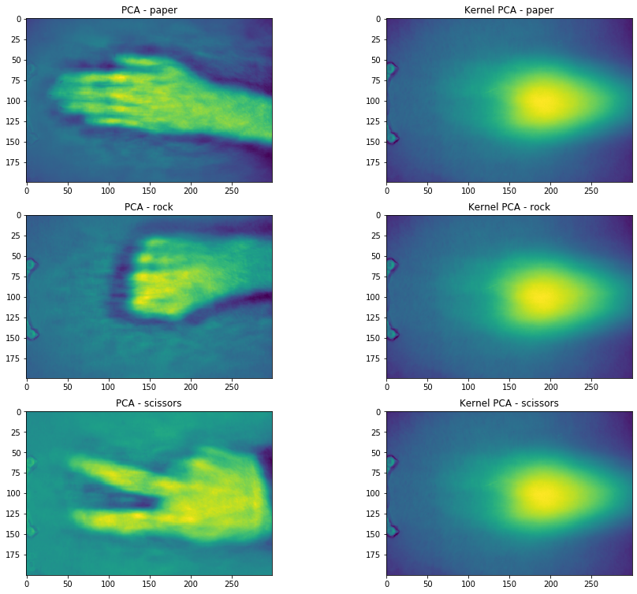

```python
plt.figure(figsize=(15,13))

plt.subplot(3,2,1)
PCA_reconstructed1 = pca.inverse_transform(X_pca[23].reshape(1, -1))
plt.imshow(PCA_reconstructed1.reshape((200,300)))
plt.title('PCA - paper')

plt.subplot(3,2,2)
Kernal_reconstructed1 = kpca.inverse_transform(X_kpca[23].reshape(1, -1))
plt.imshow(Kernal_reconstructed1.reshape((200,300)))
plt.title('Kernel PCA - paper')

plt.subplot(3,2,3)
PCA_reconstructed2 = pca.inverse_transform(X_pca[785].reshape(1, -1))
plt.imshow(PCA_reconstructed2.reshape((200,300)))
plt.title('PCA - rock')

plt.subplot(3,2,4)
Kernal_reconstructed2 = kpca.inverse_transform(X_kpca[785].reshape(1, -1))
plt.imshow(Kernal_reconstructed2.reshape((200,300)))
plt.title('Kernel PCA - rock')

plt.subplot(3,2,5)
PCA_reconstructed3 = pca.inverse_transform(X_pca[1435].reshape(1, -1))
plt.imshow(PCA_reconstructed3.reshape((200,300)))
plt.title('PCA - scissors')

plt.subplot(3,2,6)
Kernal_reconstructed3 = kpca.inverse_transform(X_kpca[1435].reshape(1, -1))
plt.imshow(Kernal_reconstructed3.reshape((200,300)))
plt.title('Kernel PCA - scissors')

plt.show()
```

We can clearly see that the PCA reconstructed pictures are way more clear than the kPCA ones. In order to quntitave the comparisong I will use SSIM - Structural Similarity Index, which numericaly show similarity between pictures. I will compare the pictures above to their corralated picture before doing the dimentionaly reduction:

```python
from skimage import data, img_as_float
from skimage.measure import compare_ssim as ssim

PCAcompare = []
Kernel_compare = []

PCAcompare.append((ssim(PCA_reconstructed1.reshape((200,300)),X_train[23])))   # paper
PCAcompare.append((ssim(PCA_reconstructed2.reshape((200,300)),X_train[785])))  # rock
PCAcompare.append((ssim(PCA_reconstructed3.reshape((200,300)),X_train[1435]))) # scissors

Kernel_compare.append((ssim(Kernal_reconstructed1.reshape((200,300)),X_train[23])))
Kernel_compare.append((ssim(Kernal_reconstructed1.reshape((200,300)),X_train[785])))
Kernel_compare.append((ssim(Kernal_reconstructed1.reshape((200,300)),X_train[1435])))

print('Comparing with reconstructed PCA: ',PCAcompare)
print('Comparing with reconstructed Kernel PCA: ',Kernel_compare)
```

```
Comparing with reconstructed PCA:  [0.9360929592663452, 0.93305549089486, 0.9476670841955186]
Comparing with reconstructed Kernel PCA:  [0.8541801108350926, 0.8771694371656692, 0.8661464682963828]
```

As we assumed before, can see from the output above, all the picture which recunstructed from the PCA has higher similiarity to the original black and white pictures before the dimentionality reductin than the recunstructed pictures from the kernel PCA. Therefore I will use the linear PCA.

### Using Daisy for feature extraction:

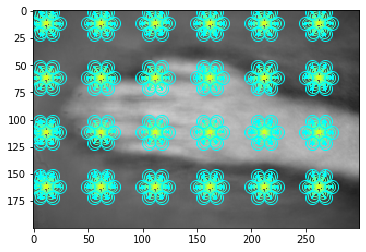

```python
from skimage.feature import daisy

img = PCA_reconstructed1.reshape((200,300))

features, img_desc = daisy(img, step=50, radius=12, rings=7,histograms=6,
                           orientations=8,visualize=True)
plt.imshow(img_desc)
plt.grid(False)
```

```python
# for later use
X_pca_reconstructed = pca.inverse_transform(X_pca)
```

[output not shown]

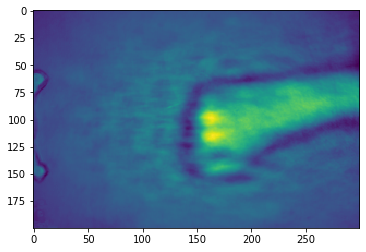

```python
#Just cheking it works
print(X_pca_reconstructed.shape)
plt.imshow(X_pca_reconstructed[608].reshape((200,300)))
```

```python
def apply_daisy(row,shape):
    feat = daisy(row.reshape(shape),step=10, radius=4, rings=1, histograms=6, orientations=3, visualize=False)
    return feat.reshape((-1))


%time test_feature = apply_daisy(X_pca_reconstructed[3],(200,300))
test_feature.shape
```

```
Wall time: 42 ms
```

```
(12600,)
```

```python
# approximation for time, tested several times in order to figure out considerable time for all the images
0.042 * len(X_pca_reconstructed)
```

```
70.56
```

```python
%time daisy_features = np.apply_along_axis(apply_daisy, 1, X_pca_reconstructed, (200,300))
print(daisy_features.shape)
```

```
Wall time: 1min 10s
(1680, 12600)
```

In order to figure out if using this feature extraction method helping my prediction task, I will build classifier using sklearn. First I will start buildong one using the daisy features:

```python
%%time
from sklearn.linear_model import LogisticRegression as SKLogisticRegression
from sklearn.metrics import accuracy_score

lr_daisy = SKLogisticRegression(solver='liblinear')

lr_daisy.fit(daisy_features,Y_train)
yhat = lr_daisy.predict(daisy_features)
print('Accuracy of: ',accuracy_score(Y_train,yhat))
```

```
Accuracy of:  0.9648809523809524
Wall time: 11.7 s
Parser   : 757 ms
```

Now, I will build classifier using the feature vectors matrix after applying the PCA:

```python
lr_pca = SKLogisticRegression(solver='liblinear')

lr_pca.fit(X_pca,Y_train)
yhat_pca = lr_pca.predict(X_pca)
print('Accuracy of: ',accuracy_score(Y_train,yhat_pca))
```

```
Accuracy of:  0.7892857142857143
```

Wow! We can clearly see a sinificant difference (17.5%!) in the accuracy results from when we are using the daisy feature extraction and when we are not using it. I can confidetly say that using daisy improved my classifier by meaningful amount.

## Exceptional Work Using SIFT

```
<class 'numpy.uint8'>
<class 'numpy.float32'>
<class 'numpy.uint8'>
```

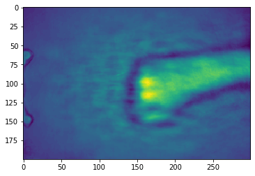

```python
# here I tested how to conver the type of my matrix from float32 to uint8
# becuase sift only accept uint8

img = cv2.imread('paper/0a3UtNzl5Ll3sq8K.png')
gray = cv2.cvtColor(img,cv2.COLOR_BGR2GRAY)
# just to check
print(type(gray[0][0]))

img2 = X_pca_reconstructed[608].reshape((200,300))
print(type(img2[0][0]))
img3=(img2*100).astype(np.uint8)
print(type(img3[0][0]))

plt.imshow(img3)
```

```
Number of matches:  23
```

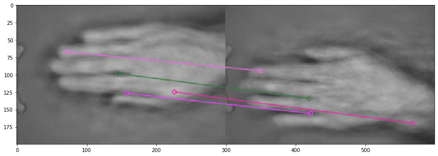

```python
# testing how to use SIFT

import cv2

sift = cv2.xfeatures2d.SIFT_create()

img1 = (X_pca_reconstructed[350].reshape((200,300))*200).astype(np.uint8)
img2 = (X_pca_reconstructed[400].reshape((200,300))*200).astype(np.uint8)

# find the keypoints and descriptors with SIFT
kp1, des1 = sift.detectAndCompute(img1,None)
kp2, des2 = sift.detectAndCompute(img2,None)

# BFMatcher with default params
bf = cv2.BFMatcher()
matches = bf.knnMatch(des1,des2, k=2)
print('Number of matches: ',len(matches))

# Apply ratio test
good = []
for m,n in matches:
    if m.distance < 0.9*n.distance:
        good.append([m])

# cv2.drawMatchesKnn expects list of lists as matches.
img3 = cv2.drawMatchesKnn(img1,kp1,img2,kp2,good,None,flags=2)

plt.figure(figsize=(15,13))
plt.imshow(img3)
plt.show()
```

Now, that I know how to use SIFT, I will build a classifier base on the k nearest nighbors which will be the pictures with the most number of good matches with a given picture. I will choose a random picture from the set and compare it with number of pictures from each class (not all of them due time cost). Base on the number of matches from the random picture, it will choose the nearest nighbors.

```
Picture at:  1651
```

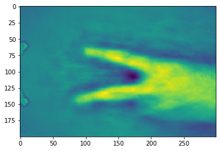

```python
# choosing random picture from the dataset:
from random import seed
from random import randint
import time

seed(time.time())
randIndx = randint(0, 1680)
print('Picture at: ',randIndx)

#fucntion for convertion to the type I need
def toUint8(indx):
    return (X_pca_reconstructed[indx].reshape((200,300))*200).astype(np.uint8)

randImg = toUint8(randIndx)
plt.imshow(randImg)
```

```python
sift = cv2.xfeatures2d.SIFT_create()
kp1, des1 = sift.detectAndCompute(randImg,None)

# building fucntion for using SIFT
# return number of good matches as a value for neighbor
def getNumofMatch(img2):

    kp2, des2 = sift.detectAndCompute(img2,None)
    bf = cv2.BFMatcher()
    matches = bf.knnMatch(des2,des1, k=2)
    good = []
    for m,n in matches:
        if m.distance < 0.5*n.distance:
            good.append([m])

    #print('Number of good: ',len(good))

    return len(good)

#number of picture from each class:
numPic = 20


# function for k nearest neighbors
def KNN(k,values):
    kHighest =[]
    for i in range(k):
        kHighest.append(values.index(max(values)))

    # 0 paper, 1 rock, 2 scissor
    countList = [0,0,0]

    for item in kHighest:
        countList[int(item/numPic)] += 1

    print(countList)
    if(countList.index(max(countList)) == 0):
        print('The picture is Paper')
    elif(countList.index(max(countList)) == 1):
        print('The picture is Rock')
    elif(countList.index(max(countList)) == 2):
        print('The picture is Scissor')


valueList = []

# checking for paper
for indx in range(10,10+numPic):
    img = toUint8(indx)
    valueList.append(getNumofMatch(img))

# rock
for indx in range(620,620+numPic):
    img = toUint8(indx)
    valueList.append(getNumofMatch(img))

# scissor
for indx in range(1640,1640+numPic):
    img = toUint8(indx)
    valueList.append(getNumofMatch(img))

# 5 nearest neigbors
KNN(5,valueList)
```

```
[0, 0, 5]
The picture is Scissor
```